# Columbia Sockeye Inseason Forecast for Counts 5/1-12/31 @ Bonneville Dam

Thomas Buehrens (tbuehrens@dfw.wa.gov)

Last Updated 07/05/2022.

# Overview

This script fits Seasonal Auto-Regressive Integrated Moving Average (SARIMA) models to in-season salmon return data to predict total return. It does this by aggregating the run-size into two periods: counts prior to a particular date (often the date of the most recent observation), and counts after that date (i.e., the remainder of the run). It then predicts the remainder of the run using the pattern of abundance before and after that date in previous years, in conjunction with covariates. This software evaluates the model’s skill at predicting the remainder of the runsize based on data collected up to a particular date. A forecast for the final year, including confidence intervals, is produced.

```r
options(width = 100)
knitr::opts_chunk$set(message = FALSE)
set.seed(123)
```

```r
wd_functions<-"functions"
sapply(FUN = source, paste(wd_functions, list.files(wd_functions), sep="/"))
```

```r
packages_list<-c("tidyverse"
                 ,"forecast"
                 ,"mgcv"
                 ,"ggplot2"
                 ,"MASS"
                 ,"RColorBrewer"
                 ,"kableExtra"
                 ,"lubridate"
                 ,"modelr"
                 ,"kableExtra"
                 ,"reshape2"
                 ,"ggfortify"
                 ,"clock"
                 ,"smooth"
                 ,"scales"
                 ,"gtools"
                 ,"CombMSC"
                 ,"here"
                 ,"MuMIn"
                 )
install_or_load_pack(pack = packages_list)
```

## User Inputs

Look at this section to see user inputs regarding the years and dates of data analyzed and covariates used.

```r
#=========
# Raw Data
#=========
yr_start<-2002
yr_end<-year(Sys.Date())
dam="BON"
species="Sock"
#===========================
# Summarization for analysis
#===========================
date_start_analysis<-ymd("2002/5/1") #this will be the first date of data used in the analysis (and this month/day first in years thereafter)
date_end_analysis<-ymd("2022/12/31") #this will be the last date of data used in the analysis (and this month/day last in years preceding)
forecast_period_start_m<-5 #this will be the month associated with the first month/day of the seasonal estimate period each year...can be after first data used to estimate it or the same
forecast_period_start_d<-1 #this will be the month day associated with the first month/day of the seasonal estimate period each year...can be after first data used to estimate it or the same
use_freshest_data = T #use all data up to "today" or only up to beginning of forecast period
last_data<-Sys.Date()
#==================
#forecasting params
#==================
leave_yrs<- 11
covariates<-c("pink_ind","lag1_log_SAR1","zl_flow","lag2_NPGO","lag2_PDO","lag1_log_SAR2","lag1_NPGO","lag1_PDO")
p1_covariates_only =c("zl_flow")
plot_results = F
first_forecast_period = 2
write_model_summaries = TRUE
find_best=T
```

## Get Raw Data

Data is loaded here a a snapshot of the data used in the analysis (before aggregation into the two periods described) is provided.

```r
dat<-get_dam_data(
  yr_start = yr_start,
  yr_end = yr_end,
  dam = dam,
  species = species
)

#=========================================================
#get PDO data
#=========================================================
PDO<-read_table("https://psl.noaa.gov/pdo/data/pdo.timeseries.ersstv5.csv",skip=1,col_names=F,comment="#")%>%
  dplyr::rename(Date=X1,PDO=X2)%>%
  filter(!PDO < -99)%>%
  mutate(Date=as.Date(Date),Month=month(Date),Year=year(Date))%>%
  group_by(Year)%>%
  add_tally()%>%
  #filter(!Month>6)%>% #use only spring (Jan-June) NPGO
  #filter(!n < 12)%>% #use only complete years
  group_by(Year)%>%
  dplyr::summarise(PDO=mean(PDO))%>%
  mutate(lag2_PDO = lag(PDO,2), lag1_PDO = lag(PDO,1))%>%
  dplyr::select(year=Year,lag2_PDO, lag1_PDO)
#=========================================================
#get NPGO data
#=========================================================
NPGO<-read_table("http://www.o3d.org/npgo/npgo.php",skip=29,col_names=F,comment="#")%>%
  filter(!is.na(X2))%>%
  dplyr::rename(Year=X1,Month=X2,NPGO=X3)%>%
  mutate(Year=as.numeric(Year))%>%
  group_by(Year)%>%
  add_tally()%>%
  #filter(!Month>6)%>% #use only spring (Jan-June) NPGO
  filter(!n < 12)%>% #use only complete years
  group_by(Year)%>%
  dplyr::summarise(NPGO=mean(NPGO))%>%
  mutate(Year=Year+1, lag1_NPGO = NPGO,lag2_NPGO = lag(NPGO))%>%
  dplyr::select(year=Year,lag1_NPGO,lag2_NPGO)
#=========================================================
#get Salmon Ocean Abundance Data
#=========================================================
OceanSalmon<-read_csv("https://raw.githubusercontent.com/tbuehrens/Salmon_Forecast_Example/main/data/pink_covariates_1952-2020.csv")%>%
  dplyr::rename(Year=year)%>%
  mutate(log_tot_pk_num = log(tot_pk_num))%>%
  dplyr::select(year=Year,log_tot_pk_num)
#=========================================================
#get PIT tag survival/age data
#=========================================================
PIT<-read_csv("data/Columbia_Sockeye_SAR_DART_6_10_2022.csv")%>%
  dplyr::rename(OutmigrationYear=year)%>%
  mutate(Year=OutmigrationYear+2)%>%
  filter(Pop=="SNA")

PIT<-PIT%>%bind_cols(data.frame(SAR1=gam(cbind(ocean1Count,juvCount-ocean1Count)~s(OutmigrationYear,k=(dim(PIT)[1]),m=1,bs="ps"),family=binomial,data=PIT)$fitted))%>%
  bind_cols(data.frame(SAR2=c(gam(cbind(ocean2Count,juvCount-ocean2Count)~s(OutmigrationYear,k=(dim(PIT)[1]-1),m=1,bs="ps"),family=binomial,data=PIT)$fitted,NA)))%>%
  mutate(lag1_log_SAR1 = log(SAR1),lag1_log_SAR2=lag(log(SAR2),1))%>%
  dplyr::select(year=Year,lag1_log_SAR1,lag1_log_SAR2)
#=========================================================
#get flow data (might affect timing)
#=========================================================
flow_site<-14128870
flow_url <- paste0("https://waterdata.usgs.gov/nwis/dv?cb_00065=on&format=rdb&site_no=",flow_site,
                   "&referred_module=sw&period=&begin_date=",yr_start,"-01-01",
                   "&end_date=",yr_end,"-12-31")
flow<-readr::read_delim(flow_url,comment = '#')%>%
  filter(agency_cd=="USGS")%>%
  dplyr::rename(date=datetime,stage_height=`113489_00065_00003`)%>%
  dplyr::select(date,stage_height)%>%
  mutate(stage_height = as.numeric(stage_height))

flow<-flow%>%
  mutate(year=year(date),month=month(date),yday=yday(date))%>%
  filter(yday <= yday(max(dat$date)) & yday >= yday(max(dat$date)-6))%>%
  group_by(year)%>%
  dplyr::summarise(zl_flow=mean(stage_height,na.rm=T), .groups = "keep")%>%
  ungroup()%>%
  mutate(zl_flow=as.vector(scale(zl_flow)))

#================================================================
dat<-dat%>%
  left_join(PDO)%>%
  left_join(NPGO)%>%
  left_join(OceanSalmon)%>%
  left_join(PIT)%>%
  left_join(flow)%>%
  mutate(pink_ind = ifelse(year>1999 & year%%2==0,0,1))

print(head(dat))
```

```
## # A tibble: 6 x 13
##   date       abundance  year species lag2_PDO lag1_PDO lag1_NPGO lag2_NPGO log_tot_pk_num
##   <date>         <dbl> <dbl> <chr>      <dbl>    <dbl>     <dbl>     <dbl>          <dbl>
## 1 2002-03-15         0  2002 Sock      -0.782   -0.742      2.08      1.89           5.95
## 2 2002-03-16         0  2002 Sock      -0.782   -0.742      2.08      1.89           5.95
## 3 2002-03-17         0  2002 Sock      -0.782   -0.742      2.08      1.89           5.95
## 4 2002-03-18         0  2002 Sock      -0.782   -0.742      2.08      1.89           5.95
## 5 2002-03-19         0  2002 Sock      -0.782   -0.742      2.08      1.89           5.95
## 6 2002-03-20         0  2002 Sock      -0.782   -0.742      2.08      1.89           5.95
## # ... with 4 more variables: lag1_log_SAR1 <dbl>, lag1_log_SAR2 <dbl>, zl_flow <dbl>,
## #   pink_ind <dbl>
```

```r
summarized_data<-prepare_data(series = dat,
                  date_start_analysis = date_start_analysis,
                  date_end_analysis = date_end_analysis,
                  forecast_period_start_m = forecast_period_start_m, #inclusive
                  forecast_period_start_d = forecast_period_start_d, #inclusive
                  use_freshest_data = use_freshest_data,
                  covariates = covariates,
                  p1_covariates_only=p1_covariates_only

                  )
```

## Results

This section present a a results table showing the performance of the prediction model in previous years as well as a forecast in the current year. The results in the table are graphed below.

```r
# if(find_best ==T){
#   best_covariates<-all_subsets(series=summarized_data$series,covariates=covariates,min=0,max=4)
#
#   saveRDS(best_covariates,"best_covariates_sockeye.rds")
# }


# results<-inseason_forecast(series=summarized_data$series,
#                   leave_yrs=leave_yrs,
#                   covariates= c("lag2_NPGO","lag1_log_SAR2","lag2_log_smolts","var_flow","zl_flow"), #use to automate variable selection: best_covariates[[1]][[best_covariates[[2]]$model_num[1]]],
#                   first_forecast_period = first_forecast_period,
#                   plot_results = plot_results,
#                   write_model_summaries = write_model_summaries,
#                   forecast_period_start_m =  forecast_period_start_m, #inclusive
#                   forecast_period_start_d =  forecast_period_start_d, #inclusive
#                   obs_period_2 = summarized_data$obs_period_2,
#                   p1_covariates_only = p1_covariates_only
#                   )

best_covariates<-readRDS("best_covariates_sockeye.rds")

best_covariates[[2]]%>%
  slice(1:10)%>%
  kbl(caption = "Table 1. Covariate Model Selection Results.",digits =3)%>%
  kable_classic(full_width = F, html_font = "Cambria")
```

Table 1. Covariate Model Selection Results.

| model_num | AICc | formula |
| --- | --- | --- |
| 107 | 63.105 | abundance ~ pink_ind + lag1_log_SAR1 + lag1_NPGO + lag1_PDO |
| 96 | 64.667 | abundance ~ pink_ind + lag1_log_SAR1 + zl_flow + lag1_NPGO |
| 41 | 65.060 | abundance ~ pink_ind + lag1_log_SAR1 + lag1_NPGO |
| 9 | 67.303 | abundance ~ pink_ind + lag1_log_SAR1 |
| 103 | 67.540 | abundance ~ pink_ind + lag1_log_SAR1 + lag2_PDO + lag1_NPGO |
| 100 | 68.063 | abundance ~ pink_ind + lag1_log_SAR1 + lag2_NPGO + lag1_NPGO |
| 46 | 68.298 | abundance ~ pink_ind + zl_flow + lag1_NPGO |
| 14 | 68.311 | abundance ~ pink_ind + lag1_NPGO |
| 105 | 69.057 | abundance ~ pink_ind + lag1_log_SAR1 + lag1_log_SAR2 + lag1_NPGO |
| 110 | 69.681 | abundance ~ pink_ind + zl_flow + lag2_NPGO + lag1_NPGO |

```r
results<-inseason_forecast_v2(series=summarized_data$series,
                  leave_yrs=leave_yrs,
                  covariates= best_covariates[[1]][best_covariates[[2]]$model_num[1:10]],
                  first_forecast_period = first_forecast_period,
                  plot_results = plot_results,
                  write_model_summaries = write_model_summaries,
                  forecast_period_start_m =  forecast_period_start_m, #inclusive
                  forecast_period_start_d =  forecast_period_start_d, #inclusive
                  obs_period_2 = summarized_data$obs_period_2,
                  p1_covariates_only = p1_covariates_only,
                  stack_metric = "MSA"
                  )

model_list<-lapply(best_covariates[[1]][best_covariates[[2]]$model_num[1:10]],function(x) paste(x,collapse = " + "))%>%
  unlist()%>%
  as_tibble()%>%
  add_rownames()%>%
  dplyr::rename(model=rowname,model_name=value)

results%>%
  filter(year==max(year))%>%
  left_join(model_list)%>%
  dplyr::select(year,model_name,predicted_abundance,`Lo 50`,`Hi 50`,`Lo 95`,`Hi 95`,Stacking_weight)%>%
  kbl(caption = "Table: Individual Ensemble Member Predictions and Weights",digits =2)%>%
  kable_classic(full_width = F, html_font = "Cambria")
```

Table: Individual Ensemble Member Predictions and Weights

| year | model_name | predicted_abundance | Lo 50 | Hi 50 | Lo 95 | Hi 95 | Stacking_weight |
| --- | --- | --- | --- | --- | --- | --- | --- |
| 2022 | pink_ind + lag1_log_SAR1 + lag1_NPGO + lag1_PDO | 642138.0 | 598298.8 | 706810.8 | 550018.5 | 927259.8 | 0.13 |
| 2022 | pink_ind + lag1_log_SAR1 + zl_flow + lag1_NPGO | 655318.0 | 604425.1 | 732539.7 | 550489.7 | 1007424.8 | 0.00 |
| 2022 | pink_ind + lag1_log_SAR1 + lag1_NPGO | 656019.9 | 605497.1 | 732210.4 | 551503.3 | 1000865.1 | 0.00 |
| 2022 | pink_ind + lag1_log_SAR1 | 599854.8 | 565403.4 | 654303.6 | 530858.5 | 860740.3 | 0.17 |
| 2022 | pink_ind + lag1_log_SAR1 + lag2_PDO + lag1_NPGO | 677434.2 | 620319.5 | 763096.2 | 558824.5 | 1062616.6 | 0.00 |
| 2022 | pink_ind + lag1_log_SAR1 + lag2_NPGO + lag1_NPGO | 641477.7 | 595411.8 | 711290.6 | 546511.4 | 959338.2 | 0.22 |
| 2022 | pink_ind + zl_flow + lag1_NPGO | 666733.3 | 610958.6 | 752160.6 | 552600.6 | 1060696.6 | 0.00 |
| 2022 | pink_ind + lag1_NPGO | 665032.4 | 610592.0 | 747822.8 | 553073.6 | 1043555.4 | 0.48 |
| 2022 | pink_ind + lag1_log_SAR1 + lag1_log_SAR2 + lag1_NPGO | 628223.4 | 587186.9 | 690014.9 | 543241.1 | 907392.3 | 0.00 |
| 2022 | pink_ind + zl_flow + lag2_NPGO + lag1_NPGO | 659779.7 | 606883.9 | 740423.8 | 551188.6 | 1029611.2 | 0.00 |
| 2022 | NA | 645807.5 | 597963.2 | 718603.3 | 547423.3 | 978994.8 | NA |

```r
if(length(unique(results$model))>1){

  results_best<-results%>%
  ungroup()%>%
  filter(model =="ensemble")
}


p_2_start_m<-summarized_data$p_2_start_m
p_2_start_d<-summarized_data$p_2_start_d


results_best%>%
  dplyr::select(!c("period","train_test"))%>%
  kbl(caption = paste0("Table 2. Forecasts of ",dam," dam counts of ",species, " from ",forecast_period_start_m,"/",forecast_period_start_d,"-",month(date_end_analysis),"/",mday(date_end_analysis)," using only past years' data for the forecast period and in-season counts from ", month(date_start_analysis),"/",mday(date_start_analysis)," through ", month(max(dat$date)),"/",mday(max(dat$date)), " in each year. Additional covariates are included in the table below."),digits =2)%>%
  kable_classic(full_width = F, html_font = "Cambria")
```

Table 2. Forecasts of BON dam counts of Sock from 5/1-12/31 using only past years’ data for the forecast period and in-season counts from 5/1 through 7/4 in each year. Additional covariates are included in the table below.

| year | species | abundance | pink_ind | lag1_log_SAR1 | lag1_NPGO | lag1_PDO | zl_flow | lag2_PDO | lag2_NPGO | lag1_log_SAR2 | predicted_abundance | Lo 50 | Hi 50 | Lo 95 | Hi 95 | obs_abundance | error | pct_error | model | Stacking_weight |
| --- | --- | --- | --- | --- | --- | --- | --- | --- | --- | --- | --- | --- | --- | --- | --- | --- | --- | --- | --- | --- |
| 2012 | Sock | 515675 | 0 | -4.98 | 0.86 | -1.57 | -1.76 | -0.74 | 1.37 | -3.35 | 567974.31 | 525539.38 | 633935.82 | 481616.48 | 880613.99 | 445906 | 52299.31 | 10% | ensemble | NA |
| 2013 | Sock | 185506 | 1 | -5.84 | 1.48 | -1.41 | -0.41 | -1.57 | 0.86 | -3.86 | 179864.10 | 165827.38 | 201117.40 | 150835.04 | 277033.14 | 137934 | -5641.90 | -3% | ensemble | NA |
| 2014 | Sock | 614177 | 0 | -5.12 | 0.35 | -0.93 | -0.46 | -1.41 | 1.48 | -5.10 | 492709.48 | 468734.77 | 529662.62 | 443767.51 | 665103.64 | 423714 | -121467.52 | -20% | ensemble | NA |
| 2015 | Sock | 510707 | 1 | -5.68 | -0.25 | 0.53 | 1.31 | -0.93 | 0.35 | -4.11 | 492749.27 | 463953.34 | 538392.59 | 435124.00 | 712720.40 | 414234 | -17957.73 | -4% | ensemble | NA |
| 2016 | Sock | 342497 | 0 | -7.55 | -1.40 | 0.80 | 0.78 | 0.53 | -0.25 | -3.70 | 413607.44 | 376665.79 | 471887.79 | 339498.16 | 692486.21 | 312441 | 71110.44 | 21% | ensemble | NA |
| 2017 | Sock | 87693 | 1 | -9.93 | -0.20 | 0.63 | 0.10 | 0.80 | -1.40 | -4.46 | 89082.49 | 82556.58 | 99872.41 | 76385.55 | 143870.90 | 72479 | 1389.49 | 2% | ensemble | NA |
| 2018 | Sock | 193816 | 0 | -11.15 | -0.86 | -0.06 | 0.41 | 0.63 | -0.20 | -5.33 | 188330.33 | 179494.88 | 202159.54 | 170515.04 | 253832.39 | 163853 | -5485.67 | -3% | ensemble | NA |
| 2019 | Sock | 63047 | 1 | -11.81 | -1.91 | -0.30 | 1.27 | -0.06 | -0.86 | -4.98 | 61061.22 | 57715.54 | 66240.97 | 54263.37 | 85277.24 | 51599 | -1985.78 | -3% | ensemble | NA |
| 2020 | Sock | 341739 | 0 | -12.35 | -2.25 | -0.03 | -0.74 | -0.30 | -1.91 | -10.37 | 298062.63 | 287089.68 | 314905.14 | 275635.04 | 375979.90 | 266548 | -43676.37 | -13% | ensemble | NA |
| 2021 | Sock | 151764 | 1 | -12.75 | -1.76 | -1.04 | 0.56 | -0.03 | -2.25 | -9.82 | 146922.85 | 135847.73 | 164027.42 | 124384.90 | 226632.84 | 115476 | -4841.15 | -3% | ensemble | NA |
| 2022 | Sock | NA | 0 | -12.99 | -0.84 | -1.57 | -1.05 | -1.04 | -1.76 | -5.39 | 645807.47 | 597963.15 | 718603.35 | 547423.27 | 978994.81 | 506050 | NA | NA | ensemble | NA |

```r
print(paste0("Mean Absolute Percent Error (MAPE) = ",mean(abs((results_best$error/results$abundance)*100),na.rm = T)))
```

```
## [1] "Mean Absolute Percent Error (MAPE) = 8.07742200147227"
```

```r
print(paste0("Median Symmetric Accuracy; MSA) = ",100*(exp(median(abs(log(results_best$predicted_abundance/results$abundance)),na.rm = T))-1)))
```

```
## [1] "Median Symmetric Accuracy; MSA) = 3.46956360351387"
```

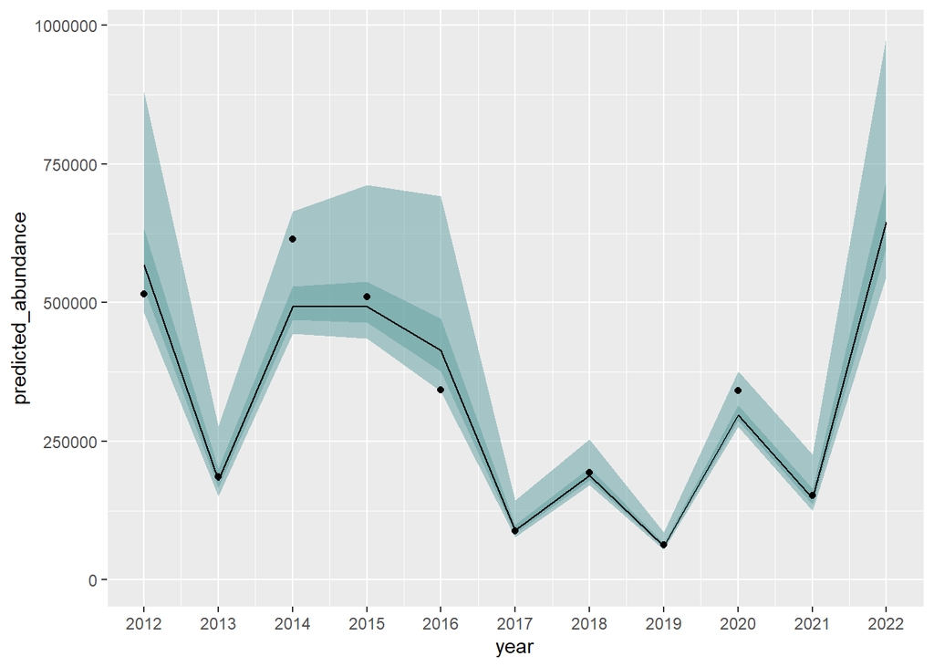

```r
p<-ggplot(results_best,aes(x=year,y=predicted_abundance))+
  geom_ribbon(aes(ymin=`Lo 95`,ymax=`Hi 95`),color=NA,alpha=0.5,fill = "cadetblue")+
  geom_ribbon(aes(ymin=`Lo 50`,ymax=`Hi 50`),color=NA,alpha=0.5,fill = "cadetblue")+
  geom_line()+
  geom_point(aes(x=year,y=abundance))+
  ylim(0,NA)+
  scale_x_continuous(breaks=unique(results$year))

print(p)
```